# NRSG 741 - Homework 2 - Exploratory Data Analysis

Melinda Higgins

February 25, 2020

## INSTRUCTIONS

- Use this Rmarkdown file `N741Spring2020_Homework02.Rmd` to get started.
- Change the author to YOUR NAME
- Change the date
- Note: This Rmarkdown file has one R code chunk at the top that reads in the dataset and loads the R packages you will need.
- After each question below, insert an R code chunk to enter the R code needed to answer that question. Do this for each question.
- Outside of the R code chunk, type in any text needed to provide explanation or answer the questions further.

## Goal of Homework 2

This homework is meant to further your `dplyr` and `ggplot2` skills.

## Modify R code chunks

In each of the R code chunks below, scaffolding is provided. Everywhere you see 3 underscores ___ , you will need to fill in the appropriate code, variable name, function name, etc.

## Abalones Dataset from UCI Repository

For this homework, you will keep working with the `abalone` dataset from the UCI data repository at https://archive.ics.uci.edu/ml/datasets/abalone.

Use tools within the `dplyr` package as much as possible to answer the following questions.

##### **Question 1:** What kind of R object is the `abalone` dataset?

```r
# insert R code here to answer question 1
# HINT: The name of the dataset is abalone

class(abalone)
```

```
## [1] "spec_tbl_df" "tbl_df"      "tbl"         "data.frame"
```

TYPE ANSWER TO QUESTION 1 HERE

The `abalone` dataset is a `data.frame` - it is also a tibble data frame (`spec_tbl_df` and `tbl_df` and `tbl`).

##### **Question 2:** How many observations are in the `abalone` dataset?

```r
# HINT: there are multiple ways to answer this - pick one
# dim(___)
# str(___)
# glimpse(___)
# nrow(___)

dim(abalone)
```

```
## [1] 4177    9
```

```r
str(abalone)
```

```
## Classes 'spec_tbl_df', 'tbl_df', 'tbl' and 'data.frame': 4177 obs. of  9 variables:
##  $ sex          : chr  "M" "M" "F" "M" ...
##  $ length       : num  0.455 0.35 0.53 0.44 0.33 0.425 0.53 0.545 0.475 0.55 ...
##  $ diameter     : num  0.365 0.265 0.42 0.365 0.255 0.3 0.415 0.425 0.37 0.44 ...
##  $ height       : num  0.095 0.09 0.135 0.125 0.08 0.095 0.15 0.125 0.125 0.15 ...
##  $ wholeWeight  : num  0.514 0.226 0.677 0.516 0.205 ...
##  $ shuckedWeight: num  0.2245 0.0995 0.2565 0.2155 0.0895 ...
##  $ visceraWeight: num  0.101 0.0485 0.1415 0.114 0.0395 ...
##  $ shellWeight  : num  0.15 0.07 0.21 0.155 0.055 0.12 0.33 0.26 0.165 0.32 ...
##  $ rings        : num  15 7 9 10 7 8 20 16 9 19 ...
##  - attr(*, "spec")=
##   .. cols(
##   ..   X1 = col_character(),
##   ..   X2 = col_double(),
##   ..   X3 = col_double(),
##   ..   X4 = col_double(),
##   ..   X5 = col_double(),
##   ..   X6 = col_double(),
##   ..   X7 = col_double(),
##   ..   X8 = col_double(),
##   ..   X9 = col_double()
##   .. )
```

```r
glimpse(abalone)
```

```
## Observations: 4,177
## Variables: 9
## $ sex           <chr> "M", "M", "F", "M", "I", "I", "F", "F", "M", "F", "F"...
## $ length        <dbl> 0.455, 0.350, 0.530, 0.440, 0.330, 0.425, 0.530, 0.54...
## $ diameter      <dbl> 0.365, 0.265, 0.420, 0.365, 0.255, 0.300, 0.415, 0.42...
## $ height        <dbl> 0.095, 0.090, 0.135, 0.125, 0.080, 0.095, 0.150, 0.12...
## $ wholeWeight   <dbl> 0.5140, 0.2255, 0.6770, 0.5160, 0.2050, 0.3515, 0.777...
## $ shuckedWeight <dbl> 0.2245, 0.0995, 0.2565, 0.2155, 0.0895, 0.1410, 0.237...
## $ visceraWeight <dbl> 0.1010, 0.0485, 0.1415, 0.1140, 0.0395, 0.0775, 0.141...
## $ shellWeight   <dbl> 0.150, 0.070, 0.210, 0.155, 0.055, 0.120, 0.330, 0.26...
## $ rings         <dbl> 15, 7, 9, 10, 7, 8, 20, 16, 9, 19, 14, 10, 11, 10, 10...
```

```r
nrow(abalone)
```

```
## [1] 4177
```

TYPE ANSWER TO QUESTION 2 HERE

The number of rows (which is the number of observations) in the `abalone` dataset is 4177.

##### **Question 3:** For diameter, how many abalones have diameters less than 0.5mm?

```r
# the variable name is diameter
# abalone %>%
#   filter(___ < ___) %>%
#   nrow()

abalone %>%
  filter(diameter < 0.5) %>%
  nrow()
```

```
## [1] 3388
```

TYPE ANSWER TO QUESTION 3 HERE

The number of abalones in the dataset with diameter < 0.5 mm is 3388.

##### **Question 4:** How many abalones have shucked weights larger than their whole weight?

NOTE: There should be NO measurements where the shucked weight is > whole weight. If there are some these are probably data entry errors in this dataset.

```r
# HINT: Use a logical expression inside a filter step
# HINT: Check the spelling and case for the
# variable names for shucked weight and whole weight
# abalone %>%
#   filter(___ > ___) %>%
#   nrow()

abalone %>%
  filter(shuckedWeight > wholeWeight) %>%
  nrow()
```

```
## [1] 4
```

TYPE ANSWER TO QUESTION 4 HERE

The number of abalones which have shucked weights recorded as larger than > their whole weights is 4.

Create a subset containing only infants `sex == "I"`. Call this new dataset `infants`

```r
# HINT: Put the logical statement inside the filter() function
# Dont forget to use the assign operator <- to create the infants object
# infants <- abalone %>%
#   filter(___ == ___)

infants <- abalone %>%
  filter(sex == "I")
```

##### **Question 5:** How many infants are in this subset?

```r
# Hint: see code in question 2 above
# pick the function you prefer to answer this question
# ___(___)

nrow(infants)
```

```
## [1] 1342
```

TYPE ANSWER TO QUESTION 5 HERE

The number of infant abalones in this dataset are 1342.

Show off your `dplyr` skills with `group_by()` - we didn’t get a chance to fully explore `group_by()` in class but it is added in the examples below to help you answer these questions.

##### **Question 6:** What is the average whole weight for each abalone sex (get whole weight means for females “F”, males “M” and infants “I” separately)?

```r
# Hint: put the variables used in the select statement
# and in the summarise() statement. Remember to put
# in a name for the output of the mean() function
# something like meanwt
# abalone %>%
#   select(sex, ___) %>%
#   group_by(sex) %>%
#   summarise(___ = mean(___, na.rm=TRUE))

abalone %>%
  select(sex, wholeWeight) %>%
  group_by(sex) %>%
  summarise(meanwt = mean(wholeWeight, na.rm=TRUE))
```

```
## # A tibble: 3 x 2
##   sex   meanwt
##   <chr>  <dbl>
## 1 F      1.05
## 2 I      0.431
## 3 M      0.991
```

TYPE ANSWER TO QUESTION 6 HERE

The output above shows the average whole weight of the abalones by sex (males, females and infants).

##### **Question 7:** Get the means for the abalone length and height by sex?

```r
# Hint: put variable names in the select statement
# put the function name for the mean in the
# summarise_all() function
# abalone %>%
#   select(sex, ___, ___) %>%
#   group_by(sex) %>%
#   summarise_all(___, na.rm=TRUE)

abalone %>%
  select(sex, length, height) %>%
  group_by(sex) %>%
  summarise_all(mean, na.rm=TRUE)
```

```
## # A tibble: 3 x 3
##   sex   length height
##   <chr>  <dbl>  <dbl>
## 1 F      0.579  0.158
## 2 I      0.428  0.108
## 3 M      0.561  0.151
```

TYPE ANSWER TO QUESTION 7 HERE

The table above provides the average length and height for the abalones by sex.

## Test your graphing skills using `ggplot2`

Using the `abalone` dataset, create the following graphics/figures using `ggplot()` and associated `geom_xxx()` functions.

##### **Question 8:** Create a histogram of abalone whole weight

BONUS: Outline the histogram bars with a black line and fill the histogram bars with a green color

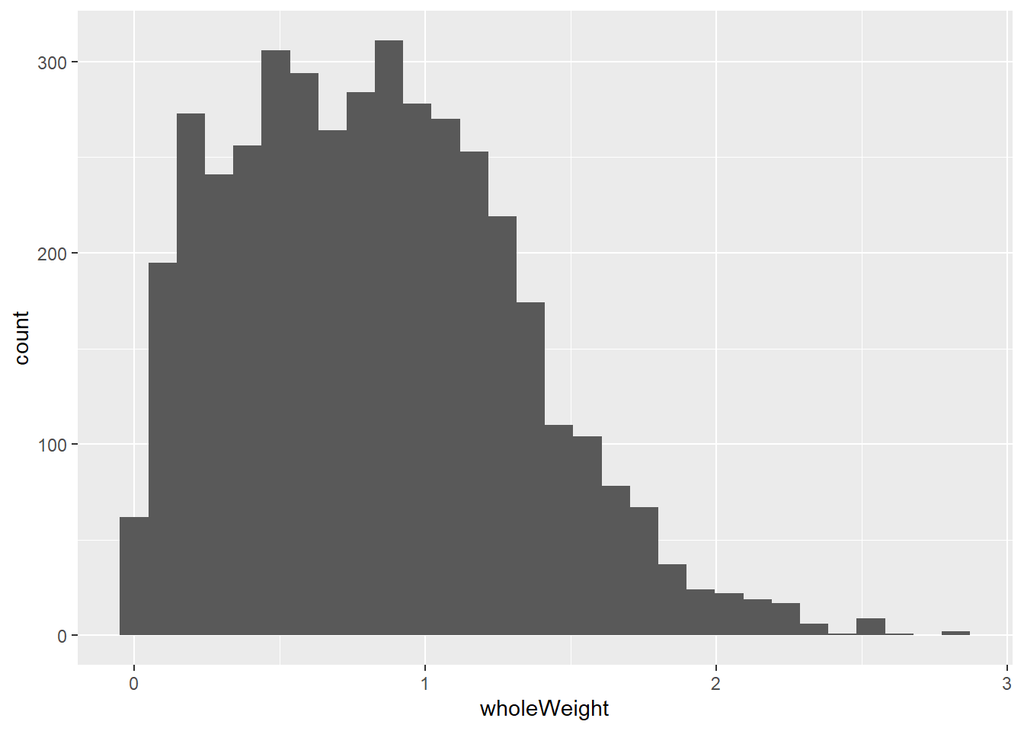

```r
# Hint: the first option in the ggplot() function
# is the name of the dataset
# the variable name is put inside aes()
# ggplot(___, aes(___)) +
#   geom_histogram()

# BONUS:
# ggplot(___, aes(___)) +
#   geom_histogram(color = ___, fill = ___)

ggplot(abalone, aes(wholeWeight)) +
  geom_histogram()
```

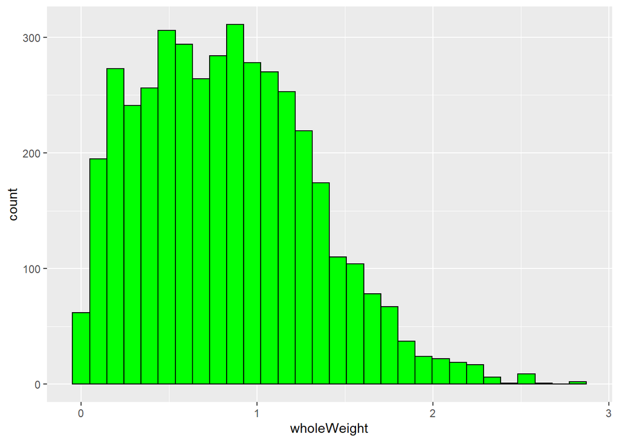

```r
# BONUS:
ggplot(abalone, aes(wholeWeight)) +
  geom_histogram(color = "black", fill = "green")
```

*What do you notice about the distribution (any outliers or skewness)?*

TYPE ANSWER TO QUESTION 8 HERE

The distribution is slightly right skewed (longer tail to the right) and the curve is slightly fatter than would be expected under a normal curve indicating some slight negative kurtosis (flatter or fatter than a normal curve).

##### **Question 9:** Create side-by-side boxplots of the number of rings by gender - color the bars by sex

*HINT use `geom_boxplot` with x = sex and y = rings*

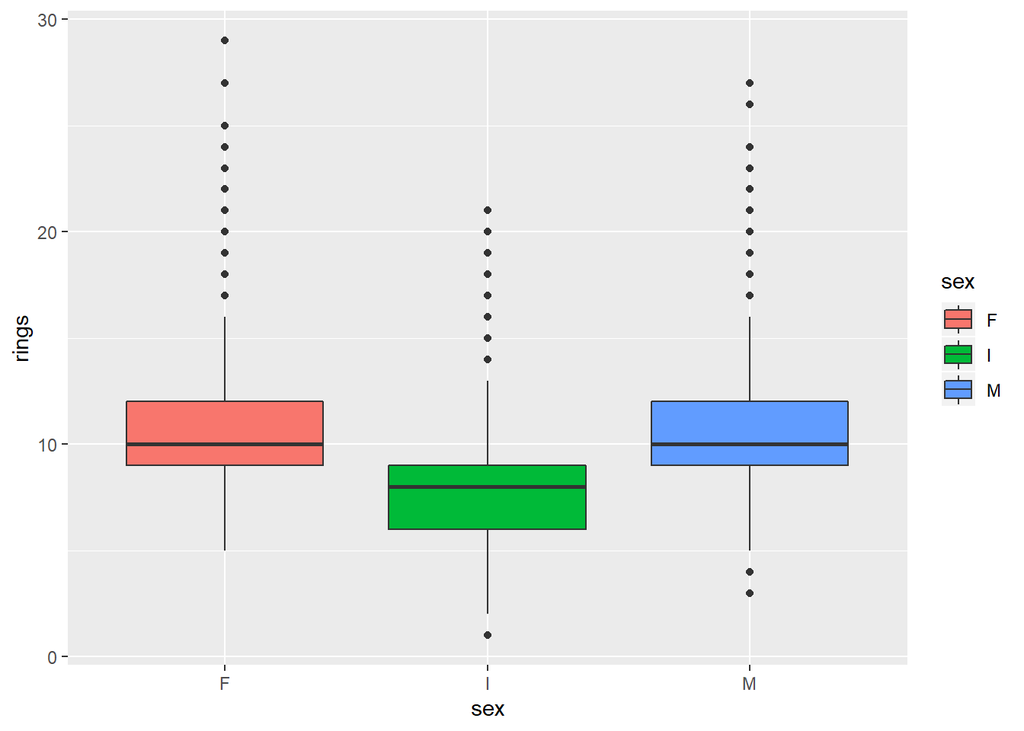

```r
# ggplot(___,
#        aes(x=___, y=___, fill=___)) +
#   geom_boxplot()

ggplot(abalone,
       aes(x=sex, y=rings, fill=sex)) +
  geom_boxplot()
```

##### **Question 10:** Create a scatterplot of the whole weight on the X axis and shucked weight on the Y axis and color the points by sex

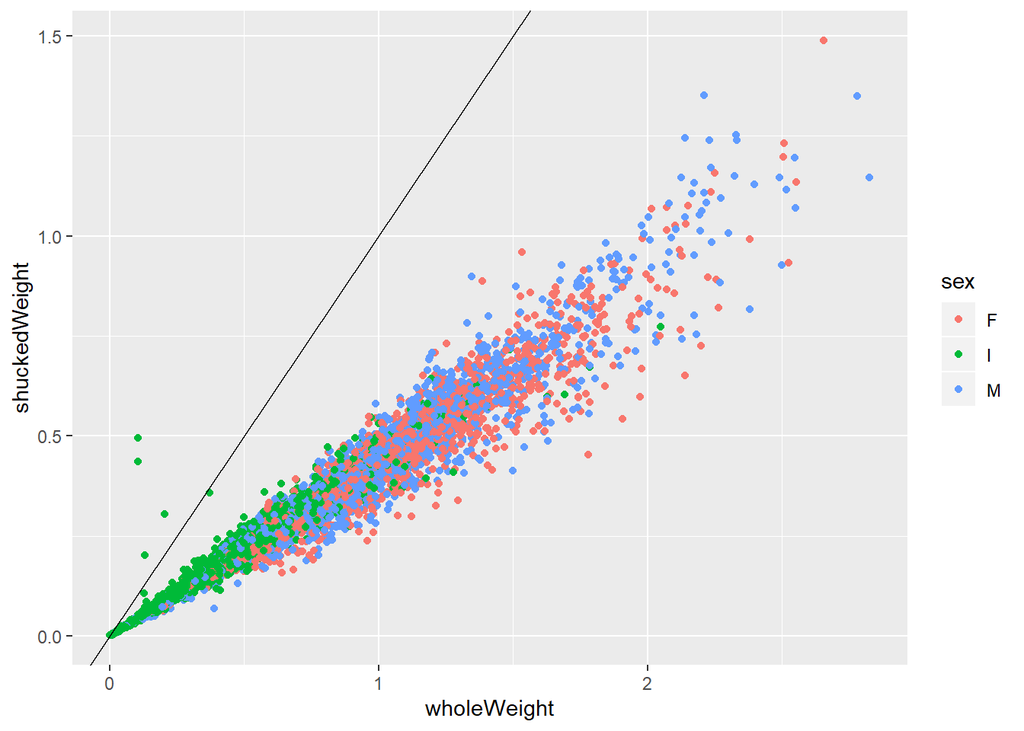

```r
# ggplot(___,
       # aes(x=___, y=___, color=___)) +
  # geom_point() +
  # geom_abline(intercept = 0, slope = 1)

ggplot(abalone,
       aes(x=wholeWeight, y=shuckedWeight, color=sex)) +
  geom_point() +
  geom_abline(intercept = 0, slope = 1)
```

Can you see which abalones have shucked weights > whole weights which should not happen? Look at the y=x reference line. What sex are the abalones with the incorrect weights?

From the plot above, it appears that there are 4 abalones that have shucked weights > their whole weight and all 4 are infants (green points).

## Final Instructions

- KNIT this RMD file to PDF (or to HTML or DOC and save as PDF)
- Upload your PDF document to Canvas